# Final_Project_STAT497

Sidar Yük

2024-01-21

```r
#install.packages("TSA")
library(TSA)
#install.packages('forecast')
library(forecast)
#install.packages("fpp")
library(fpp)
#install.packages("tidyverse")
library(tidyverse)
#install.packages("tibbletime")
library(tibbletime)
#install.packages("anomalize")
library(anomalize)
#install.packages("gridExtra")
library(gridExtra)
#install.packages("fUnitRoots")
library(fUnitRoots)
#install.packages("pdR")
library(pdR)
#install.packages("uroot")
library(uroot)
#install.packages("fpp2")
library(fpp2)
```

**INRODUCTION**  
Data includes information about the unemployment rate in the USA. This data is only based on one demographic variable, which is black and African American people. The data were obtained from a monthly survey of about 60,000 households

```r
data <- read.csv("LNU04000006.csv")
head(data)
```

```
##         DATE LNU04000006
## 1 1972-01-01        11.6
## 2 1972-02-01        11.5
## 3 1972-03-01        10.7
## 4 1972-04-01         9.2
## 5 1972-05-01         9.3
## 6 1972-06-01        11.8
```

```r
colnames(data) <- c('month', "rate")
class(data)
```

```
## [1] "data.frame"
```

my data looks as data.frame, so ı have to convert it to time series data

```r
mydata <- ts(data[,2], start = 1972, frequency = 12)
mydata
```

```
##       Jan  Feb  Mar  Apr  May  Jun  Jul  Aug  Sep  Oct  Nov  Dec
## 1972 11.6 11.5 10.7  9.2  9.3 11.8 11.8 10.3 10.3  9.9  9.7  8.7
## 1973  9.4  9.7  9.4  9.3  8.7 11.4 11.1  9.0  9.6  8.2  8.9  8.3
## 1974  9.9 10.0  9.9  9.0  8.8 11.6 11.5  9.7 10.6 10.7 11.9 12.3
## 1975 14.9 15.0 15.6 14.8 14.1 16.4 15.3 14.7 15.0 14.0 13.9 13.7
## 1976 15.0 15.1 13.9 13.3 12.3 15.6 15.1 14.0 13.3 13.2 13.4 13.3
## 1977 14.4 14.8 14.1 12.2 12.7 15.2 15.1 14.9 14.0 13.9 14.1 12.8
## 1978 14.5 13.5 13.2 12.3 12.2 14.0 14.2 12.2 11.6 11.4 12.3 11.7
## 1979 12.7 13.7 12.5 12.2 11.7 13.5 13.3 12.3 11.4 12.0 11.4 11.5
## 1980 13.2 13.2 12.9 13.2 13.8 15.8 16.4 14.6 14.4 14.8 14.5 14.3
## 1981 14.6 15.1 15.1 14.1 14.3 16.9 16.0 16.3 15.7 16.4 16.2 16.5
## 1982 17.3 17.9 18.2 17.8 18.0 19.7 19.7 18.9 19.5 19.9 19.5 20.2
## 1983 21.3 20.1 20.3 20.2 19.9 21.7 20.3 19.7 18.7 18.0 16.8 17.1
## 1984 17.1 16.3 16.7 16.4 15.4 16.4 17.6 16.1 15.0 15.2 14.3 14.4
## 1985 15.0 16.1 15.2 15.0 15.1 15.2 16.0 14.3 15.1 14.7 15.0 14.2
```

[output cut: 38 more lines]

```r
class(mydata)
```

```
## [1] "ts"
```

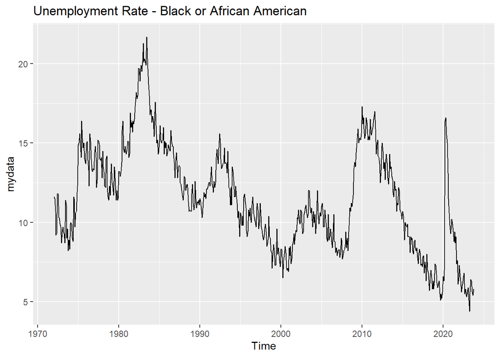

```r
autoplot(mydata, main = "Unemployment Rate - Black or African American")
```

When we look at the plot, we see both increasing and decreasing trends. There is an increasing trend from the 1970s to the end of 1980. A decreasing trend has been noticeable since this date. Also, seasonality can be seen, and when we look at 2020, the graph suddenly peaked, which may be due to outliers  
# **ANOMALY DETECTİON and SPLİT**

```r
df <- data
df$month <- paste(df$month, "01", sep="-")
df$month <- as.Date(df$month,format="%Y-%m-%d")
df <- df %>% select(month,rate)
df <- as_tibble(df)
class(df)
```

```
## [1] "tbl_df"     "tbl"        "data.frame"
```

```r
head(df)
```

```
## # A tibble: 6 × 2
##   month       rate
##   <date>     <dbl>
## 1 1972-01-01  11.6
## 2 1972-02-01  11.5
## 3 1972-03-01  10.7
## 4 1972-04-01   9.2
## 5 1972-05-01   9.3
## 6 1972-06-01  11.8
```

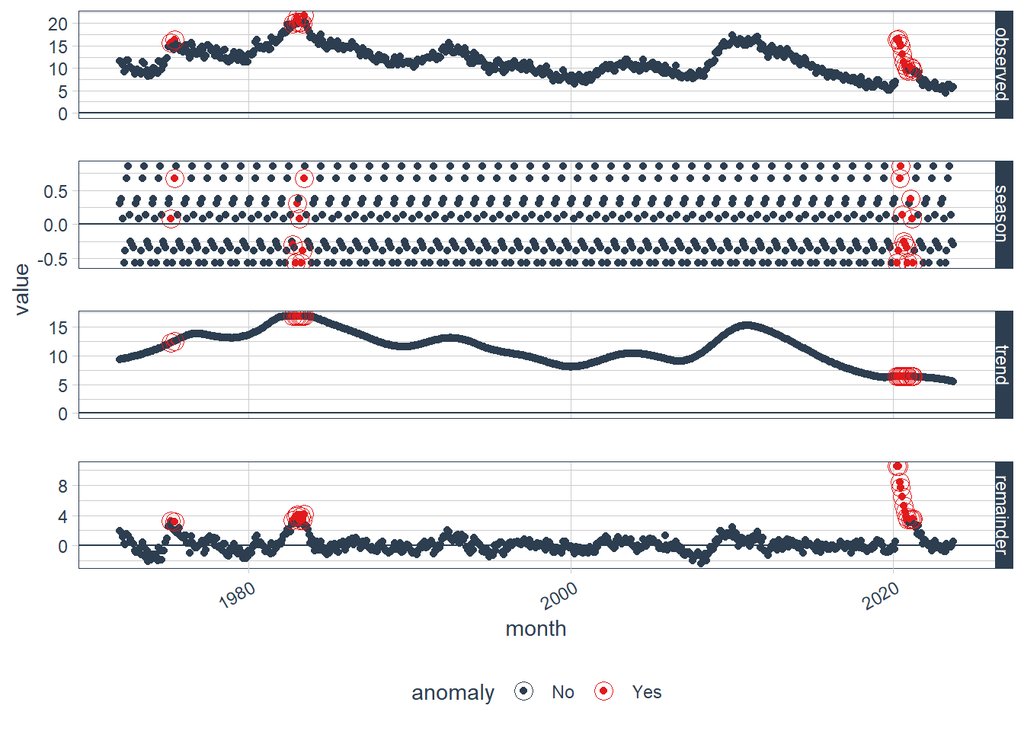

```r
df %>%
  time_decompose(rate, method = "stl", frequency = "auto", trend = "auto") %>%
  anomalize(remainder, method = "gesd", alpha = 0.05, max_anoms = 0.2) %>%
  plot_anomaly_decomposition()
```

plots show that about 1975, 1983, and 2021 include most of the outliers

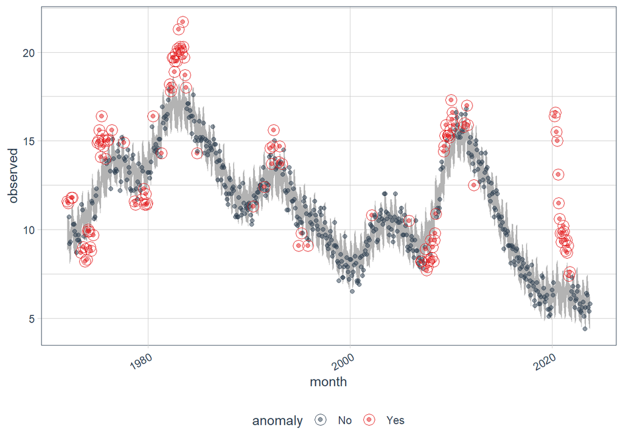

```r
df %>%
  time_decompose(rate) %>%
  anomalize(remainder,alpha=0.5) %>%
  time_recompose() %>%
  plot_anomalies(time_recomposed = TRUE, ncol = 3, alpha_dots = 0.5)
```

Anomaly Detection and Plotting the detected anomalies are almost similar to what we saw above with Time Series Decomposition. It’s just that decomposed components after anomaly detection are recomposed back with time_recompose() and plotted with plot_anomalies(). The package itself automatically takes care of a lot of parameter settings like index, frequency, and trend, making it easier to run anomaly detection out of the box with less prior expertise in the same domain

```r
df %>%
  time_decompose(rate) %>%
  anomalize(remainder) %>%
  time_recompose() %>%
  filter(anomaly == 'Yes')
```

```
## # A time tibble: 9 × 10
## # Index:         month
##   month      observed season trend remainder remainder_l1 remainder_l2 anomaly
##   <date>        <dbl>  <dbl> <dbl>     <dbl>        <dbl>        <dbl> <chr>
## 1 1983-01-01     21.3  0.310 16.9       4.08        -3.94         4.02 Yes
## 2 1983-06-01     21.7  0.673 16.9       4.12        -3.94         4.02 Yes
## 3 2020-04-01     16.4 -0.566  6.43     10.5         -3.94         4.02 Yes
## 4 2020-05-01     16.6 -0.387  6.44     10.5         -3.94         4.02 Yes
## 5 2020-06-01     15.5  0.673  6.45      8.37        -3.94         4.02 Yes
## 6 2020-07-01     15    0.859  6.47      7.68        -3.94         4.02 Yes
## 7 2020-08-01     13.1  0.133  6.46      6.51        -3.94         4.02 Yes
## 8 2020-09-01     11.5 -0.253  6.45      5.31        -3.94         4.02 Yes
## 9 2020-10-01     10.6 -0.303  6.44      4.47        -3.94         4.02 Yes
## # ℹ 2 more variables: recomposed_l1 <dbl>, recomposed_l2 <dbl>
```

you can see the anomaly points

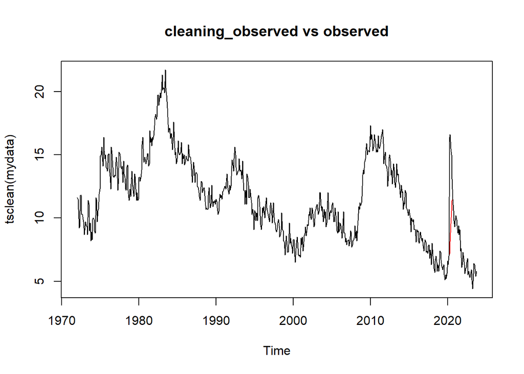

```r
plot(tsclean(mydata), main = "cleaning_observed vs observed", col = "red")
lines(mydata, col = "black") # original data set
```

The plot shows that outliers in the data is replaced by smoothed values in additon to missing values

## Split  
our data is monthly data, so the test has to be 12 observations

```r
mydata <- tsclean(mydata)
train <- window(mydata, end=c(2022,10))
train
```

```
##            Jan       Feb       Mar       Apr       May       Jun       Jul
## 1972 11.600000 11.500000 10.700000  9.200000  9.300000 11.800000 11.800000
## 1973  9.400000  9.700000  9.400000  9.300000  8.700000 11.400000 11.100000
## 1974  9.900000 10.000000  9.900000  9.000000  8.800000 11.600000 11.500000
## 1975 14.900000 15.000000 15.600000 14.800000 14.100000 16.400000 15.300000
## 1976 15.000000 15.100000 13.900000 13.300000 12.300000 15.600000 15.100000
## 1977 14.400000 14.800000 14.100000 12.200000 12.700000 15.200000 15.100000
## 1978 14.500000 13.500000 13.200000 12.300000 12.200000 14.000000 14.200000
## 1979 12.700000 13.700000 12.500000 12.200000 11.700000 13.500000 13.300000
## 1980 13.200000 13.200000 12.900000 13.200000 13.800000 15.800000 16.400000
## 1981 14.600000 15.100000 15.100000 14.100000 14.300000 16.900000 16.000000
## 1982 17.300000 17.900000 18.200000 17.800000 18.000000 19.700000 19.700000
## 1983 21.300000 20.100000 20.300000 20.200000 19.900000 21.700000 20.300000
## 1984 17.100000 16.300000 16.700000 16.400000 15.400000 16.400000 17.600000
## 1985 15.000000 16.100000 15.200000 15.000000 15.100000 15.200000 16.000000
```

[output cut: 89 more lines]

```r
test <- window(mydata, start = c(2022,11))
test
```

```
##      Jan Feb Mar Apr May Jun Jul Aug Sep Oct Nov Dec
## 2022                                         5.4 5.3
## 2023 5.6 5.9 5.1 4.4 5.6 6.4 6.3 5.6 5.4 5.8
```

**BOX-COX TRANSFORMATION**

```r
lambda <- BoxCox.lambda(train)
lambda
```

```
## [1] 0.9076419
```

the lambda value is not equal to 1, so we need to apply box-cox transformation

```r
train2 <- BoxCox(train, lambda)
train2
```

```
##            Jan       Feb       Mar       Apr       May       Jun       Jul
## 1972  9.089604  9.009829  8.369276  7.155955  7.237382  9.248962  9.248962
## 1973  7.318728  7.562291  7.318728  7.237382  6.747572  8.929991  8.690086
## 1974  7.724280  7.805160  7.724280  6.992854  6.829418  9.089604  9.009829
## 1975 11.689655 11.767551 12.233929 11.611712 11.064722 12.853205 12.000951
## 1976 11.767551 11.845398 10.907983 10.436503  9.646277 12.233929 11.845398
## 1977 11.299446 11.611712 11.064722  9.566935  9.963054 11.923198 11.845398
## 1978 11.377587 10.593877 10.357734  9.646277  9.566935 10.986378 11.143014
## 1979  9.963054 10.751036  9.804783  9.566935  9.169314 10.593877 10.436503
## 1980 10.357734 10.357734 10.121095 10.357734 10.829536 12.389017 12.853205
## 1981 11.455678 11.845398 11.845398 11.064722 11.221255 13.238829 12.543925
## 1982 13.546569 14.006953 14.236608 13.930323 14.083544 15.379763 15.379763
## 1983 16.590305 15.683223 15.834743 15.759000 15.531563 16.891605 15.834743
## 1984 13.392782 12.775951 13.084708 12.853205 12.078657 12.853205 13.776942
## 1985 11.767551 12.621311 11.923198 11.767551 11.845398 11.923198 12.543925
```

[output cut: 89 more lines]

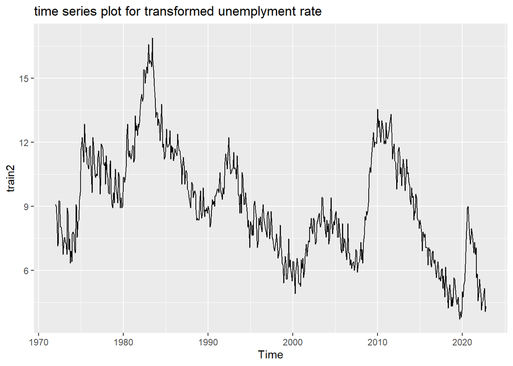

```r
autoplot(train2, main = "time series plot for transformed unemplyment rate")
```

after applying the box-cox transformation, the transformed series is not stationary. Let’s look at ACF AND PACF of the series  
**ACF AND PACF**

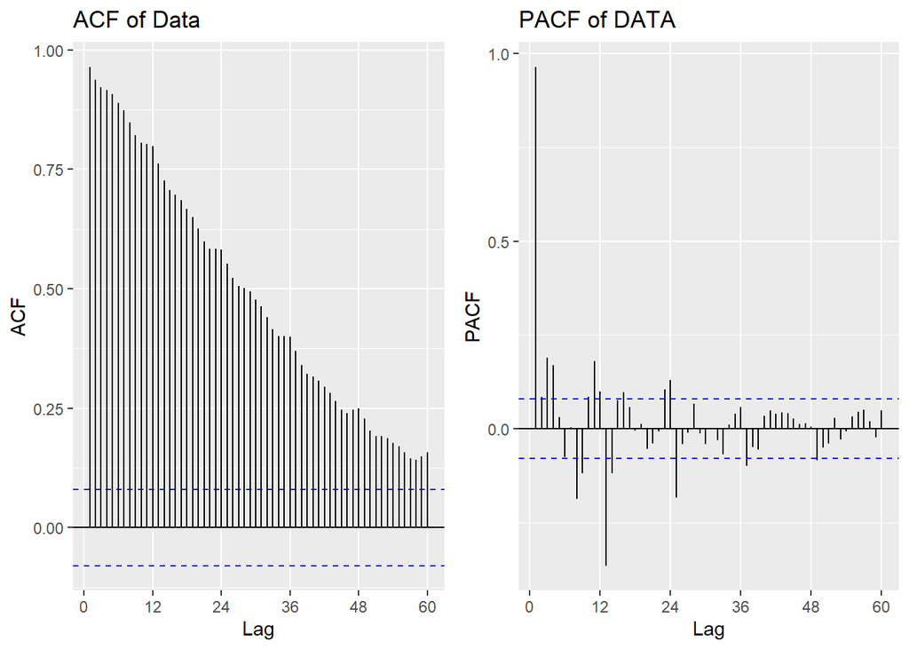

```r
acf <- ggAcf(train2,lag.max = 60,main = "ACF of Data")
pacf <- ggPacf(train2,lag.max = 60,main = "PACF of DATA")
grid.arrange(acf,pacf, nrow = 1)
```

ACF shows slow decay. This is an indicator of nonstationary. We cannot interpret PACF  
**KPSS**

```r
kpss.test(train2,c("Level"))
```

```
##
##  KPSS Test for Level Stationarity
##
## data:  train2
## KPSS Level = 2.6486, Truncation lag parameter = 6, p-value = 0.01
```

The p-value of the KPSS test is 0.01, which is less than 0.05, so we have enough evidence to conclude that “the series is not stationary.”

```r
kpss.test(train2,null=c("Trend"))
```

```
##
##  KPSS Test for Trend Stationarity
##
## data:  train2
## KPSS Trend = 0.33555, Truncation lag parameter = 6, p-value = 0.01
```

The p-value of the KPSS test for trend is 0.01, which is less than 0.05, so we have enough evidence to conclude that “the series has a stochastic trend.”  
**PP**

```r
pp.test(train2)
```

```
##
##  Phillips-Perron Unit Root Test
##
## data:  train2
## Dickey-Fuller Z(alpha) = -15.946, Truncation lag parameter = 6, p-value
## = 0.2202
## alternative hypothesis: stationary
```

Since p value is greater than α=0.05 , we fail to reject H0 . It means that we don’t have enough evidence to claim that we have a stationary system  
**ADF**

```r
mean(train2)
```

```
## [1] 9.045979
```

The mean of the transformed series is not equal to 0; the type argument should be c. Also, lags = 1 because 1st lag is significant in PACF

```r
adfTest(train2, lags=1, type = "c")
```

```
##
## Title:
##  Augmented Dickey-Fuller Test
##
## Test Results:
##   PARAMETER:
##     Lag Order: 1
##   STATISTIC:
##     Dickey-Fuller: -2.5162
##   P VALUE:
##     0.1201
##
## Description:
##  Mon Feb 26 17:56:38 2024 by user: sidar
```

The p-value of the ADF test is higher than 0.05, so we have no enough evidence to conclude that” the series is stationary. We make adfTest again with argument type ct

```r
adfTest(train2, lags=1, type = "ct")
```

```
##
## Title:
##  Augmented Dickey-Fuller Test
##
## Test Results:
##   PARAMETER:
##     Lag Order: 1
##   STATISTIC:
##     Dickey-Fuller: -3.2488
##   P VALUE:
##     0.07952
##
## Description:
##  Mon Feb 26 17:56:38 2024 by user: sidar
```

The p-value of the ADF test for trend is 0.07, which is higher than 0.05. therefore, we have no enough evidence to conclude that “the series has a deterministic trend,” so the series has a stochastic trend (unit root)  
**HEGY**

```r
out <- HEGY.test(wts=train2, itsd=c(1,1,0), regvar=0, selectlags=list(mode="signf", Pmax=NULL))
out$stats
```

```
##               Stat.    p-value
## tpi_1     -2.295074 0.10000000
## tpi_2     -3.931398 0.01000000
## Fpi_3:4    4.645366 0.01000000
## Fpi_5:6   15.173211 0.01000000
## Fpi_7:8    3.120438 0.04739824
## Fpi_9:10  12.117939 0.01000000
## Fpi_11:12 10.449421 0.01000000
## Fpi_2:12   8.003627         NA
## Fpi_1:12   7.733910         NA
```

p values of tpi_1 are higher than 0.05, so the system has a regular unit, and p values of Fpi_7:8 are very close to 0.05, so we need to check them with the test  
**CANOVA-HANSEN**

```r
ch.test(train2,type = "dummy",sid=c(1:12)) #since we have monthly data, we use sid=c(1:12)
```

```
##
##  Canova and Hansen test for seasonal stability
##
## data:  train2
##
##      statistic pvalue
## [1,]    2.5605 0.1463
## ---
## Signif. codes: 0 '***' 0.001 '**' 0.01 '*' 0.05 '.' 0.1 ' ' 1
##
## Test type: seasonal dummies
## NW covariance matrix lag order: 19
## First order lag: no
## Other regressors: no
## P-values: interpolation in original tables
```

Since the p-value (0.1463) is greater than α, we fail to reject H0. The seasonal pattern is purely deterministic and stationary  
**DETRENDING or DIFFERENCING**

```r
ndiffs(train2)#number of regular  differences to be taken to achieve the stationary in mean.
```

```
## [1] 1
```

```r
nsdiffs(diff(train2)) # number of seasonal difference after taking regular difference
```

```
## [1] 1
```

```r
dif_data = diff(train2)
```

```r
kpss.test(dif_data,null=c("Level"))
```

```
##
##  KPSS Test for Level Stationarity
##
## data:  dif_data
## KPSS Level = 0.084606, Truncation lag parameter = 6, p-value = 0.1
```

The p-value of the KPSS test is 0.1, which is higher than 0.05, so we cannot reject the null hypothesis, and we can conclude that the differenced series is stationary

```r
mean(dif_data)
```

```
## [1] -0.007814118
```

mean around zero, so type = nc

```r
adfTest(dif_data, type="nc")
```

```
##
## Title:
##  Augmented Dickey-Fuller Test
##
## Test Results:
##   PARAMETER:
##     Lag Order: 1
##   STATISTIC:
##     Dickey-Fuller: -22.521
##   P VALUE:
##     0.01
##
## Description:
##  Mon Feb 26 17:56:39 2024 by user: sidar
```

The p-value of the ADF test is 0.01, which is less than 0.05, so we can reject the null hypothesis and we can conclude that the differenced series is stationary

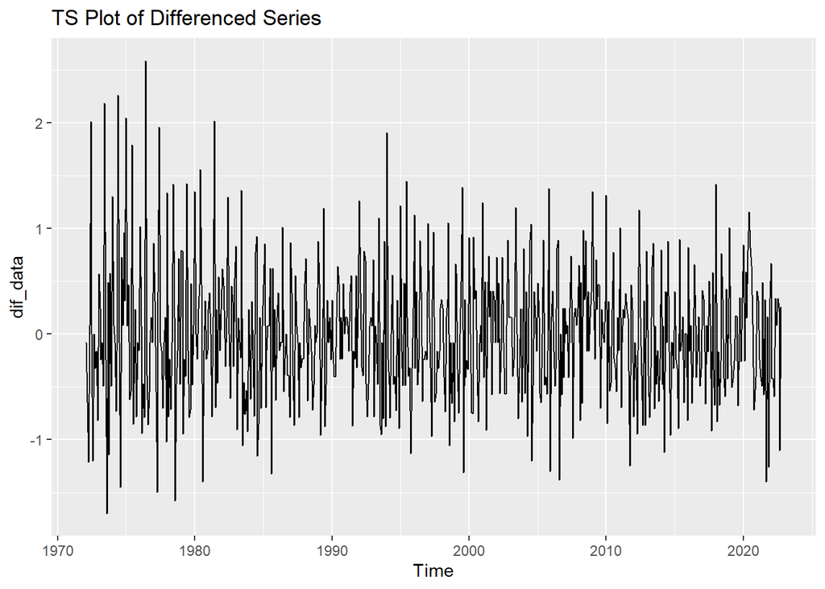

```r
autoplot(dif_data,main="TS Plot of Differenced Series")
```

After taking differencing, As you see the trend is removed. Then, check ACF and PACF

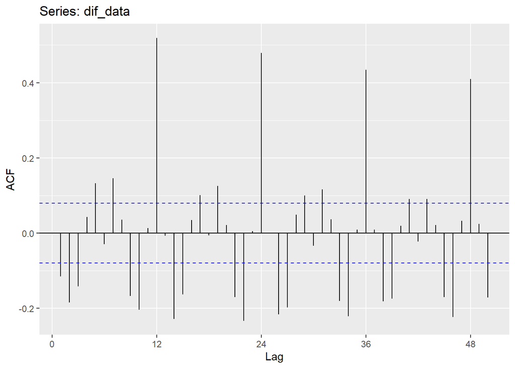

```r
ggAcf(dif_data, lag.max = 50)
```

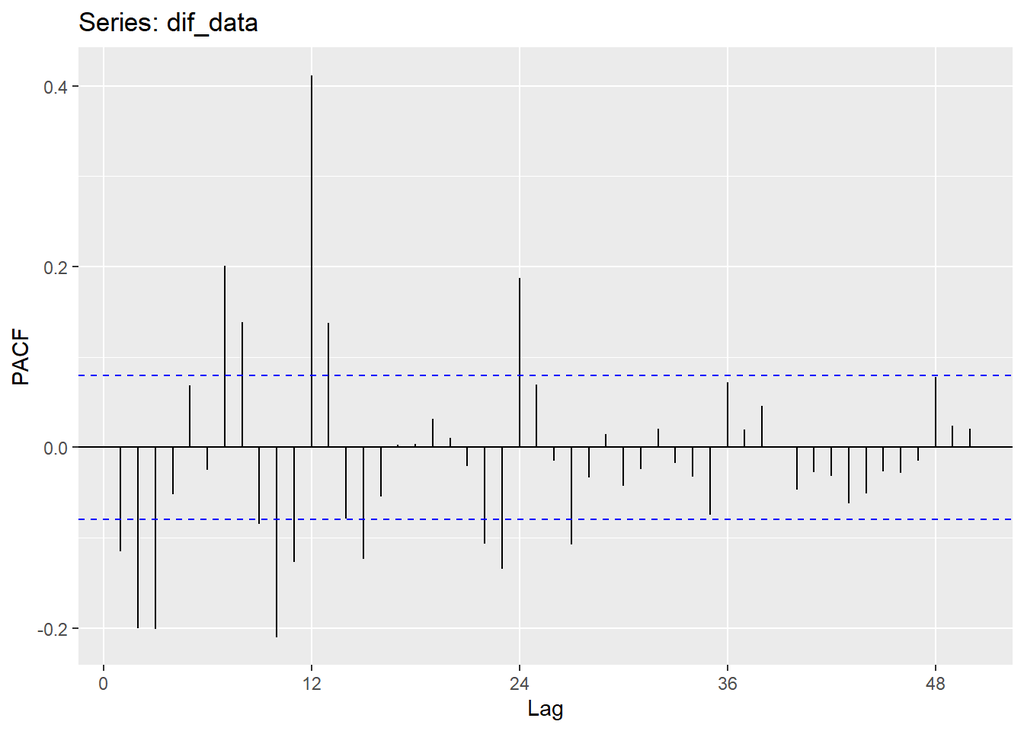

```r
ggPacf(dif_data, lag.max = 50)
```

It is seen that we have linear decay on the seasonal lags (12,24,36,48…) in ACF, which represents the non-stationarity of the series..  
## Hegy Test for Differenced Series

```r
out2 <- HEGY.test(wts=dif_data, itsd=c(1,0,0), regvar=0, selectlags=list(mode="signf", Pmax=NULL))
out2$stats
```

```
##               Stat.    p-value
## tpi_1     -3.778556 0.01000000
## tpi_2     -2.571765 0.01000000
## Fpi_3:4    4.425463 0.01391405
## Fpi_5:6   16.003475 0.01000000
## Fpi_7:8    2.432484 0.09486128
## Fpi_9:10  11.129681 0.01000000
## Fpi_11:12 11.909353 0.01000000
## Fpi_2:12   7.545731         NA
## Fpi_1:12   7.161646         NA
```

Hegy test shows that differenced series has a seasonal unit root. To remove this, we need to take the seasonal difference

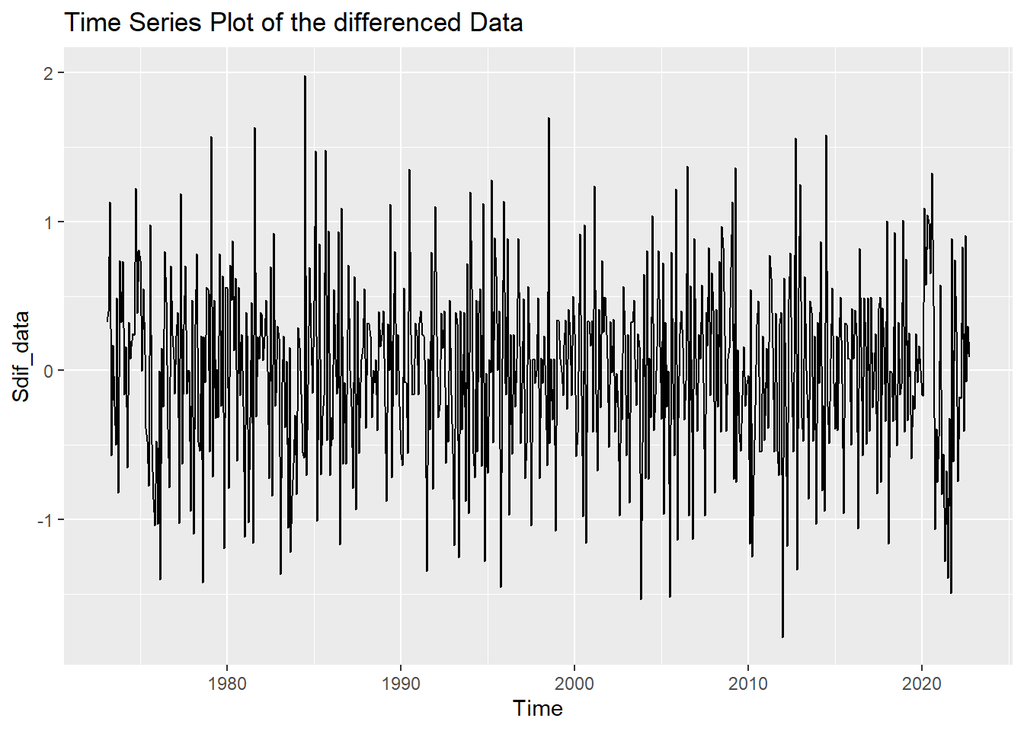

```r
Sdif_data = diff(dif_data,12) #  #12 is the frequency of the dataset
autoplot(Sdif_data, main = "Time Series Plot of the differenced Data")
```

seems better rather than the previous plot and now we get rid of seasonal unit root.

```r
out3 <- HEGY.test(wts=Sdif_data, itsd=c(0,0,0), regvar=0, selectlags=list(mode="signf", Pmax=NULL))
out3$stats
```

```
##                Stat. p-value
## tpi_1     -11.082115    0.01
## tpi_2      -9.370632    0.01
## Fpi_3:4   150.054090    0.01
## Fpi_5:6   156.712992    0.01
## Fpi_7:8   132.383646    0.01
## Fpi_9:10  100.557539    0.01
## Fpi_11:12 101.281147    0.01
## Fpi_2:12   45.222509      NA
## Fpi_1:12   41.476559      NA
```

After taking regular and seasonal difference, we have no unit root problem  
**PROPER ARIMA/SARIMA MODEL**

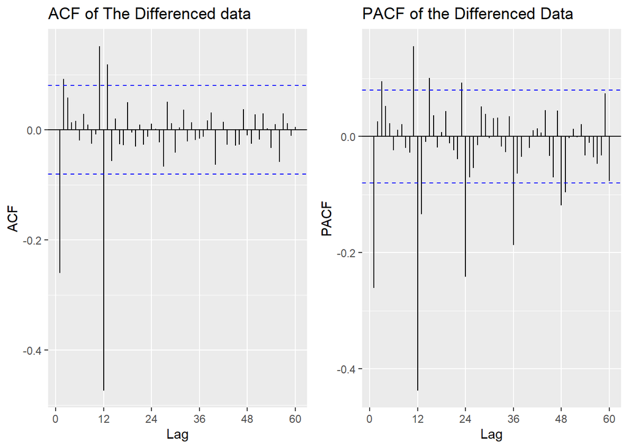

```r
p1<-ggAcf(Sdif_data,lag.max=60,main = "ACF of The Differenced data")
p2<-ggPacf(Sdif_data,lag.max=60, main = "PACF of the Differenced Data")
grid.arrange(p1,p2,nrow=1)
```

`suggest_1: SARIMA(1, 1, 4)(4, 1, 1)12`

`suggest_2: SARIMA(1, 1, 2)(4, 1, 1)12`

`suggest_3: SARIMA(3, 1, 1)(4, 1, 1)12`

`suggest_4: SARIMA(3, 1, 2)(4, 1, 1)12`  
**MODEL IDENTIFICATION and PARAMETER ESTIMATION**

```r
fit1<-Arima(train2,order = c(1, 1, 4), seasonal = c(4, 1, 1))
fit1
```

```
## Series: train2
## ARIMA(1,1,4)(4,1,1)[12]
##
## Coefficients:
##          ar1      ma1     ma2      ma3      ma4    sar1    sar2    sar3    sar4
##       0.7984  -1.0622  0.3010  -0.0139  -0.0036  0.0815  0.0537  0.0066  0.0154
## s.e.  0.1465   0.1511  0.0719   0.0609   0.0492  0.0548  0.0510  0.0491  0.0488
##          sma1
##       -0.8857
## s.e.   0.0378
##
## sigma^2 = 0.2205:  log likelihood = -398.37
## AIC=818.75   AICc=819.2   BIC=867.06
```

ar1 and sma1 are significant ma4 and sar4 is not significant

```r
fit2<-Arima(train2,order = c(1, 1, 4), seasonal = c(3, 1, 1))
fit2
```

```
## Series: train2
## ARIMA(1,1,4)(3,1,1)[12]
##
## Coefficients:
##          ar1      ma1     ma2      ma3      ma4    sar1    sar2    sar3
##       0.7963  -1.0595  0.2996  -0.0144  -0.0030  0.0766  0.0502  0.0042
## s.e.  0.1492   0.1537  0.0720   0.0608   0.0492  0.0533  0.0502  0.0488
##          sma1
##       -0.8804
## s.e.   0.0355
##
## sigma^2 = 0.2201:  log likelihood = -398.42
## AIC=816.85   AICc=817.22   BIC=860.77
```

ar1 and sma1 are significant ma4 and sar3 is not significant

```r
fit3 <- Arima(train2,order = c(1, 1, 4), seasonal = c(2, 1, 1))
fit3
```

```
## Series: train2
## ARIMA(1,1,4)(2,1,1)[12]
##
## Coefficients:
##          ar1      ma1     ma2      ma3      ma4    sar1    sar2     sma1
##       0.7950  -1.0583  0.2994  -0.0148  -0.0025  0.0755  0.0493  -0.8791
## s.e.  0.1495   0.1540  0.0721   0.0607   0.0491  0.0519  0.0493   0.0322
##
## sigma^2 = 0.2198:  log likelihood = -398.43
## AIC=814.86   AICc=815.16   BIC=854.38
```

ar1 and sma1 are significant ma4 and sar2 is not significant

```r
fit4 <-  Arima(train2,order = c(1, 1, 4), seasonal = c(1, 1, 1))
fit4
```

```
## Series: train2
## ARIMA(1,1,4)(1,1,1)[12]
##
## Coefficients:
##          ar1      ma1     ma2      ma3     ma4    sar1     sma1
##       0.7888  -1.0533  0.2947  -0.0147  0.0033  0.0606  -0.8623
## s.e.  0.1505   0.1547  0.0721   0.0605  0.0492  0.0516   0.0315
##
## sigma^2 = 0.2198:  log likelihood = -398.93
## AIC=813.85   AICc=814.1   BIC=848.99
```

ar1 and sma1 are significant ma4 and sar1 are not significant

```r
fitz <- Arima(train2,order = c(1, 1, 4), seasonal = c(0, 1, 1))
fitz
```

```
## Series: train2
## ARIMA(1,1,4)(0,1,1)[12]
##
## Coefficients:
##          ar1      ma1     ma2      ma3     ma4     sma1
##       0.8180  -1.0818  0.3017  -0.0155  0.0003  -0.8394
## s.e.  0.1284   0.1339  0.0698   0.0615  0.0476   0.0291
##
## sigma^2 = 0.2201:  log likelihood = -399.61
## AIC=813.21   AICc=813.4   BIC=843.96
```

ar1 and sma1 are significant ma4 is not significant

```r
fit5 <- Arima(train2,order = c(1, 1, 3), seasonal = c(0, 1, 1))
fit5
```

```
## Series: train2
## ARIMA(1,1,3)(0,1,1)[12]
##
## Coefficients:
##          ar1      ma1     ma2      ma3     sma1
##       0.8197  -1.0835  0.3023  -0.0156  -0.8394
## s.e.  0.1124   0.1198  0.0695   0.0490   0.0290
##
## sigma^2 = 0.2198:  log likelihood = -399.61
## AIC=811.21   AICc=811.36   BIC=837.56
```

ar1 and sma1 are significant ma3 is not significant

```r
fit6 <- Arima(train2,order = c(1, 1, 2), seasonal = c(0, 1, 1))
fit6
```

```
## Series: train2
## ARIMA(1,1,2)(0,1,1)[12]
##
## Coefficients:
##          ar1      ma1     ma2     sma1
##       0.8005  -1.0614  0.2841  -0.8400
## s.e.  0.1076   0.1094  0.0399   0.0289
##
## sigma^2 = 0.2194:  log likelihood = -399.66
## AIC=809.31   AICc=809.42   BIC=831.27
```

ar1, sma1 and ma2 is significant

```r
fit7 <- Arima(train2,order = c(1, 1, 1), seasonal = c(0, 1, 1))
fit7
```

```
## Series: train2
## ARIMA(1,1,1)(0,1,1)[12]
##
## Coefficients:
##           ar1     ma1     sma1
##       -0.2735  0.0221  -0.8418
## s.e.   0.1250  0.1276   0.0286
##
## sigma^2 = 0.2226:  log likelihood = -404.55
## AIC=817.1   AICc=817.17   BIC=834.67
```

ar1 and sma1 are significant ma1 is not significant

```r
fit3a <- Arima(train2, order = c(3, 1, 2), seasonal = c(0, 1, 1))
fit3a
```

```
## Series: train2
## ARIMA(3,1,2)(0,1,1)[12]
##
## Coefficients:
##          ar1     ar2     ar3      ma1     ma2     sma1
##       0.6292  0.1210  0.0390  -0.8928  0.1311  -0.8387
## s.e.  0.7839  0.4653  0.2187   0.7861  0.6605   0.0294
##
## sigma^2 = 0.2201:  log likelihood = -399.6
## AIC=813.21   AICc=813.4   BIC=843.95
```

sma1 is significant ma2 and ar3 are not significant

```r
fit3b <- Arima(train2,order = c(3, 1, 2), seasonal = c(1, 1, 1))
fit3b
```

```
## Series: train2
## ARIMA(3,1,2)(1,1,1)[12]
##
## Coefficients:
##          ar1     ar2     ar3      ma1     ma2    sar1     sma1
##       0.6639  0.0824  0.0233  -0.9283  0.1795  0.0602  -0.8617
## s.e.  0.8430  0.4884  0.2341   0.8449  0.7004  0.0518   0.0319
##
## sigma^2 = 0.2198:  log likelihood = -398.93
## AIC=813.87   AICc=814.11   BIC=849
```

sma1 is significant ar3, ma2, and sar 1 are not significant

```r
fit8 <- Arima(train2,order = c(1, 1, 0), seasonal = c(0, 1, 1))
fit8
```

```
## Series: train2
## ARIMA(1,1,0)(0,1,1)[12]
##
## Coefficients:
##           ar1     sma1
##       -0.2528  -0.8422
## s.e.   0.0396   0.0285
##
## sigma^2 = 0.2222:  log likelihood = -404.56
## AIC=815.13   AICc=815.17   BIC=828.3
```

ar1 and sma1 are significant

```r
fit9 <- auto.arima(train2)
fit9
```

```
## Series: train2
## ARIMA(1,1,2)(2,0,0)[12]
##
## Coefficients:
##          ar1      ma1     ma2    sar1    sar2
##       0.7322  -0.9671  0.2458  0.3880  0.3451
## s.e.  0.1432   0.1436  0.0427  0.0384  0.0396
##
## sigma^2 = 0.2532:  log likelihood = -447.57
## AIC=907.14   AICc=907.28   BIC=933.61
```

Among the models,fit6, fit8 and fit9 are significant,fit8 has the lowest BIC value as 828.3 so we can continue our analysis with SARIMA(1,1,0)(0,1,1)12  
# **DIAGNISTIC CHECKING**  
## Evaluating Residuals

```r
r=resid(fit8)/sd(residuals(fit8))
head(r)
```

```
##                Jan           Feb           Mar           Apr           May
## 1972  0.0112632224  0.0049044423  0.0020488058 -0.0007694926 -0.0004557637
##                Jun
## 1972  0.0035921486
```

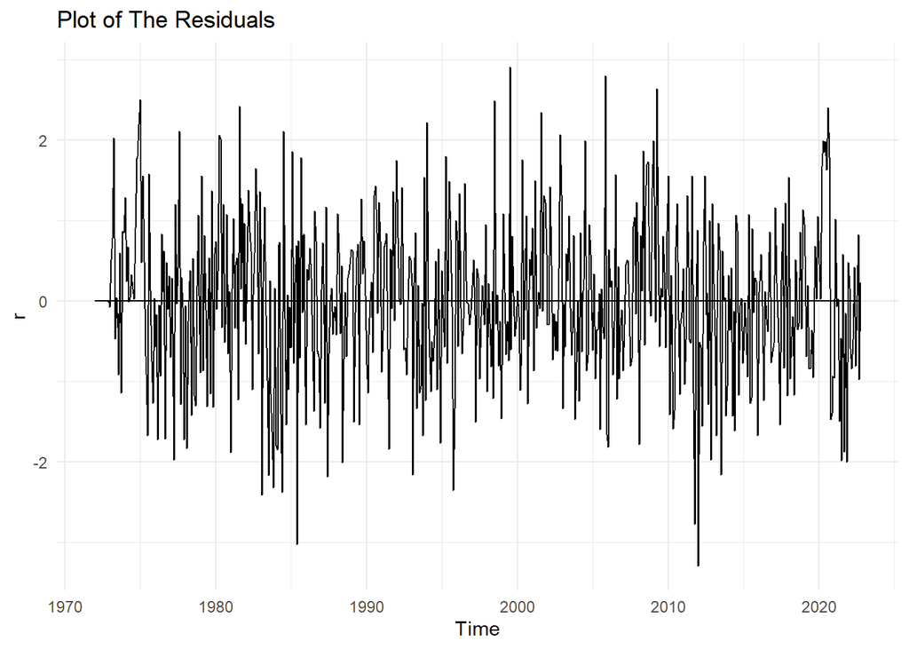

```r
autoplot(r)+geom_line(y=0)+theme_minimal()+ggtitle("Plot of The Residuals")
```

They are scattered around zero and it can be interpreted as zero mean

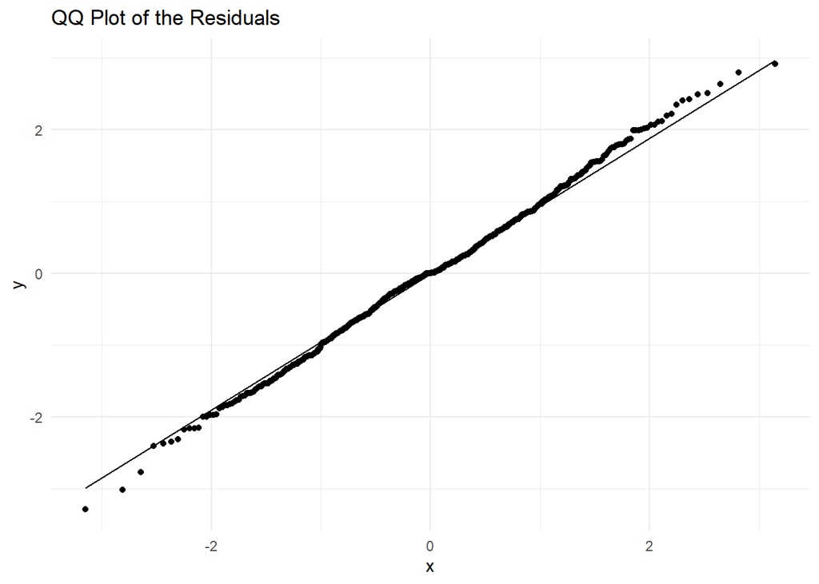

```r
ggplot(r, aes(sample = r)) +stat_qq()+geom_qq_line()+ggtitle("QQ Plot of the Residuals")+theme_minimal()
```

QQ Plot shows that most of the residuals of the model lie on 45 degree straight line.This indicates residuals are normally distributed

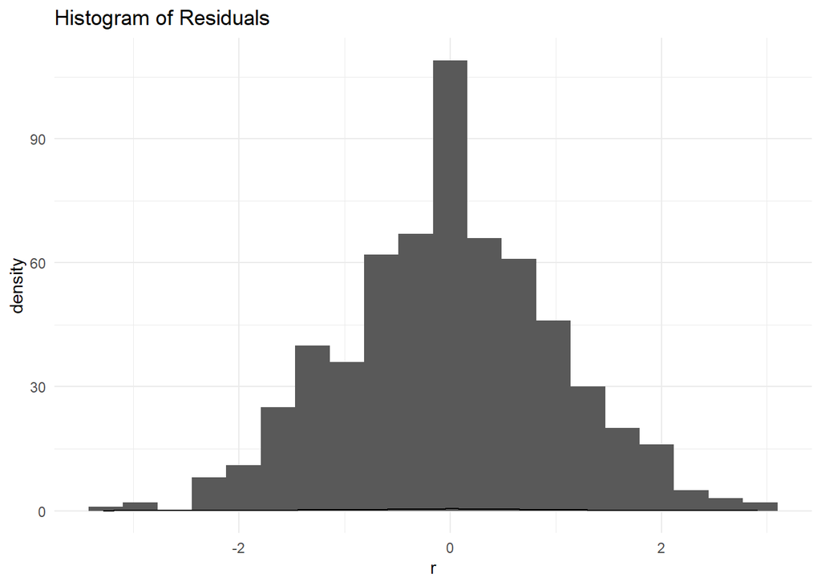

```r
ggplot(r,aes(x=r))+geom_histogram(bins=20)+geom_density()+ggtitle("Histogram of Residuals")+theme_minimal()
```

Histogram of the resiudals shows that they might have a symmetric distribution  
## Formal Normality Tests

```r
jarque.bera.test(r)
```

```
##
##  Jarque Bera Test
##
## data:  r
## X-squared = 0.14746, df = 2, p-value = 0.9289
```

```r
shapiro.test(r)
```

```
##
##  Shapiro-Wilk normality test
##
## data:  r
## W = 0.99779, p-value = 0.6129
```

both jargue bera and shapiro-wilk test indicate residuals are normally disributed because p-values > 0.05  
## Detection of Serial correlation

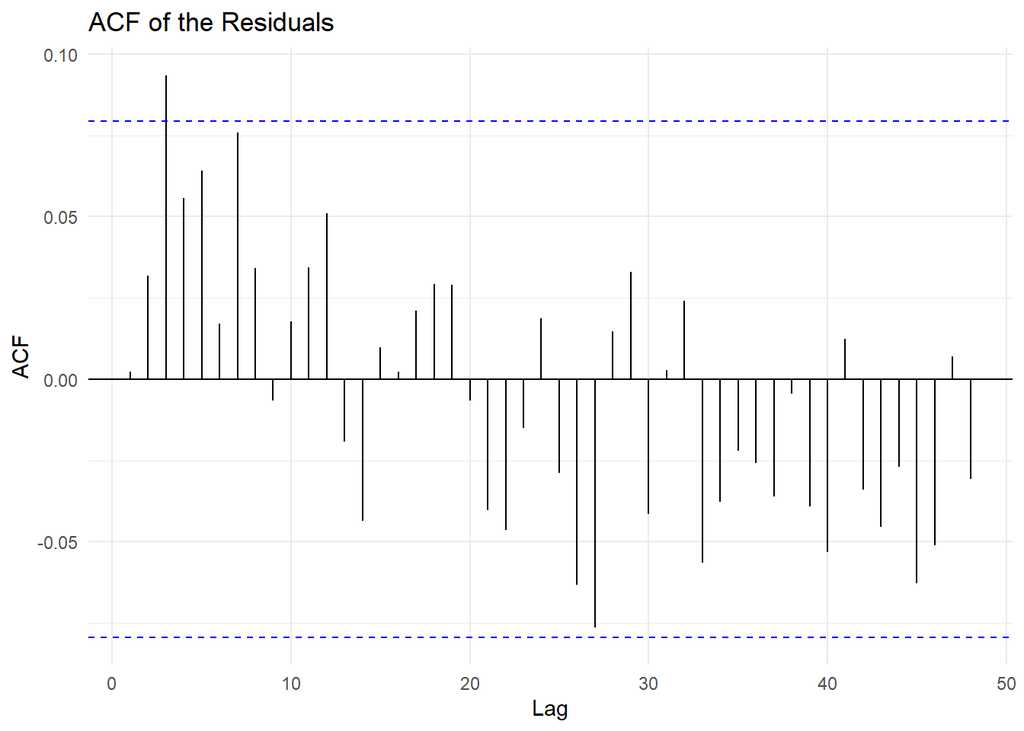

```r
ggAcf(as.vector(r),main="ACF of the Residuals",lag = 48)+theme_minimal()
```

In the ACF, almost all spikes are in the WN band which shows that there is no serial correlation in the residuals to be sure, we have to apply formal test  
There are three tests used for detecting serial correlation among residuals. For all tests, we have the following hypothesis  
H0: there is no serial correlation of any order up to p p1=….=pp=0 H1: there is a serial correlation up to p / ρi≠0

```r
library(lmtest)
library(TSA)
```

### Breusch-Godfrey Test

```r
m = lm(r ~ 1+zlag(r))
bgtest(m,order=12)
```

```
##
##  Breusch-Godfrey test for serial correlation of order up to 12
##
## data:  m
## LM test = 14.194, df = 12, p-value = 0.2885
```

Since p value is greater than alpha, we have 95% confident that the residuals of the model are uncorrelated, according to results of Breusch-Godfrey Test.  
### Box-Ljung Test

```r
Box.test(r,lag=12,type = c("Ljung-Box"))
```

```
##
##  Box-Ljung test
##
## data:  r
## X-squared = 17.511, df = 12, p-value = 0.1314
```

Since p value is greater than alpha, we have 95% confident that the residuals of the model are uncorrelated, according to results of Box-Ljung Test  
### Box-Pierce Test

```r
Box.test(r,lag=12,type = c("Box-Pierce"))
```

```
##
##  Box-Pierce test
##
## data:  r
## X-squared = 17.291, df = 12, p-value = 0.139
```

Since p value is greater than alpha, we have 95% confident that the residuals of the model are uncorrelated, according to results of Box-Pierce Test  
## Heteroscedasticity Test

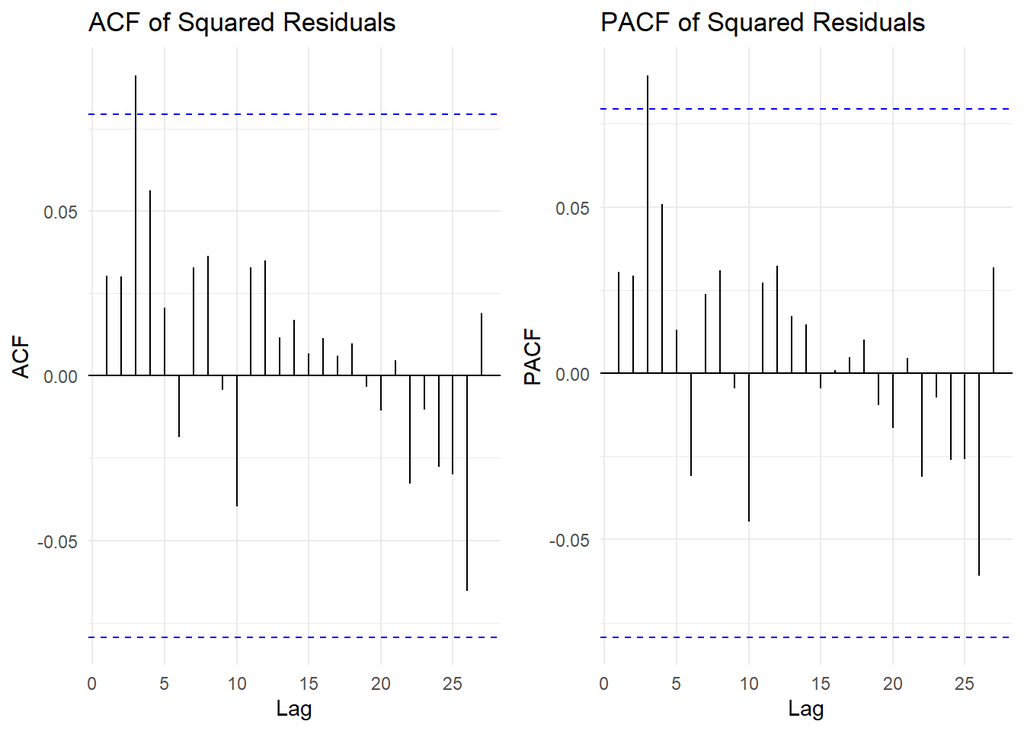

```r
rr=r^2
g1<-ggAcf(as.vector(rr))+theme_minimal()+ggtitle("ACF of Squared Residuals")
g2<-ggPacf(as.vector(rr))+theme_minimal()+ggtitle("PACF of Squared Residuals")
grid.arrange(g1,g2,ncol=2)
```

Both plots shows that almost all spikes are in of the white noise bands that is an indication of homoscedasticity. To be sure, let us apply formal test  
### Engle’s ARCH Test

```r
#install.packages("FinTS")
library(FinTS)
ArchTest(r)
```

```
##
##  ARCH LM-test; Null hypothesis: no ARCH effects
##
## data:  r
## Chi-squared = 9.865, df = 12, p-value = 0.6278
```

Since ARCH Engle’s Test yields p-value > 0.05, it can be concluded that there is no Heteroscedasticity problem.  
**FORECASTING**

```r
library(forecast)
f <- forecast(fit8,h=12)
f
```

```
##          Point Forecast    Lo 80    Hi 80    Lo 95    Hi 95
## Nov 2022       3.836419 3.232308 4.440531 2.912510 4.760329
## Dec 2022       3.793064 3.038927 4.547202 2.639710 4.946419
## Jan 2023       4.495490 3.596139 5.394842 3.120051 5.870929
## Feb 2023       4.300893 3.281346 5.320440 2.741631 5.860156
## Mar 2023       4.152790 3.024741 5.280838 2.427588 5.877991
## Apr 2023       3.677970 2.451222 4.904718 1.801821 5.554119
## May 2023       3.823682 2.505548 5.141817 1.807769 5.839595
## Jun 2023       4.273325 2.869755 5.676895 2.126749 6.419900
## Jul 2023       4.493104 3.009006 5.977203 2.223371 6.762837
## Aug 2023       4.451877 2.891401 6.012353 2.065334 6.838419
## Sep 2023       3.808128 2.174842 5.441414 1.310232 6.306024
## Oct 2023       3.857279 2.154293 5.560265 1.252786 6.461771
```

firstly apply back-transformation to the data to check the performance of the SARIMA model

```r
f_t <- InvBoxCox(f$mean,lambda)
accuracy(f_t,test)
```

```
##                  ME      RMSE       MAE       MPE     MAPE      ACF1 Theil's U
## Test set 0.05957033 0.4117525 0.3703203 0.5521146 6.761488 0.1606977 0.6597386
```

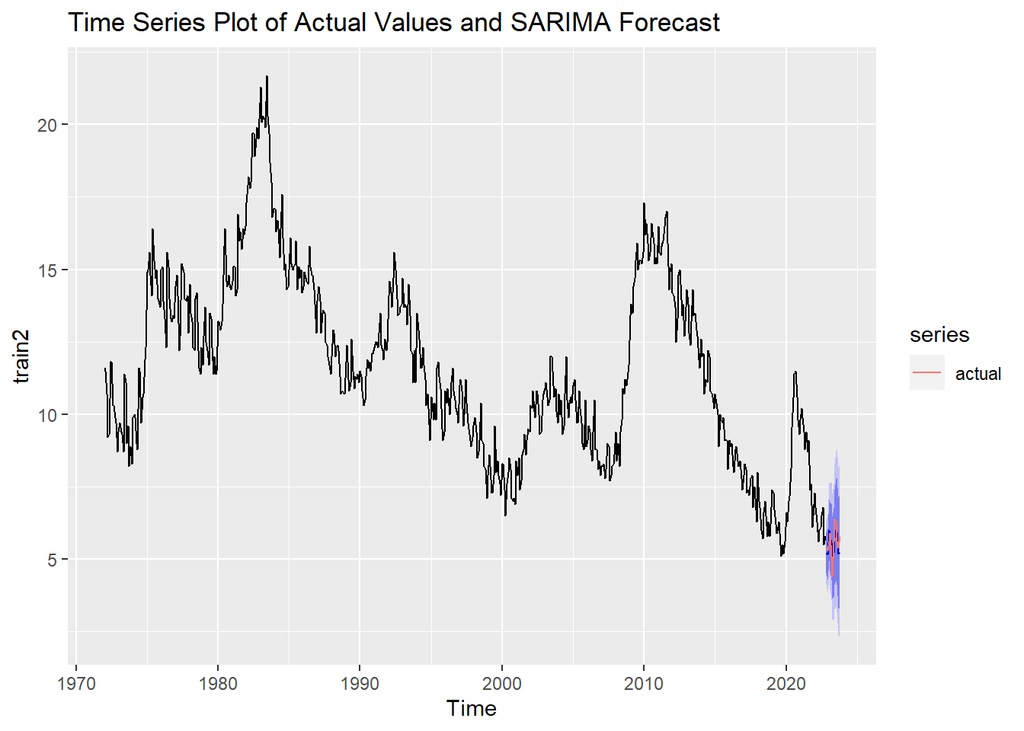

```r
f$x <- InvBoxCox(train2,lambda)
f$lower <- InvBoxCox(f$lower,lambda)
f$mean <- InvBoxCox(f$mean,lambda)
f$upper <- InvBoxCox(f$upper,lambda)
autoplot(f,main=c("Time Series Plot of Actual Values and SARIMA Forecast"), series="forecast" ) + autolayer(test,series = "actual")
```

```r
accuracy(f, test)
```

```
##                      ME      RMSE       MAE        MPE      MAPE      MASE
## Training set 2.53672474 2.6629946 2.5367247 22.0001093 22.000109 1.7652980
## Test set     0.05957033 0.4117525 0.3703203  0.5521146  6.761488 0.2577046
##                   ACF1 Theil's U
## Training set 0.5694558        NA
## Test set     0.1606977 0.6597386
```

# **ETS**

```r
new_train <- window(mydata, end=c(2022,10))
new_test <- window(mydata, start = c(2022,11))

myfit1 <- ets(new_train,model = "ZZZ")
frets1 <- forecast(myfit1,h=12)
myfit2 <- ets(new_train, model = "MMM")
frets2 <- forecast(myfit2, h = 12)
myfit3 <- ets(new_train, model = "MAM")
frets3 <- forecast(myfit3, h = 12)
myfit4 <- ets(new_train, model = "AAN")
frets4 <- forecast(myfit4, h = 12)
```

## Accuracy

```r
train_rmse <- c(
  accuracy(frets1, new_test)[1,2],
  accuracy(frets2, new_test)[1,2],
  accuracy(frets3, new_test)[1,2],
  accuracy(frets4, new_test)[1,2]
)
test_rmse <- c(
  accuracy(frets1, new_test)[2,2],
  accuracy(frets2, new_test)[2,2],
  accuracy(frets3, new_test)[2,2],
  accuracy(frets4, new_test)[2,2]
)


rmse_matrix <- matrix(c(train_rmse, test_rmse), ncol = 2, byrow = TRUE)
colnames(rmse_matrix) <- c("Train RMSE", "Test RMSE")
rownames(rmse_matrix) <- c("AAA", "MMM", "MAM", "AAN")

print(rmse_matrix)
```

```
##     Train RMSE Test RMSE
## AAA  0.5783691 0.6158632
## MMM  0.6167292 0.7993513
## MAM  0.5465442 0.4122022
## AAN  0.4291321 0.5455093
```

```r
accuracy(frets3, new_test)
```

```
##                        ME      RMSE       MAE        MPE     MAPE      MASE
## Training set -0.007842145 0.6167292 0.4870053 -0.2216273 4.352900 0.3389053
## Test set     -0.186758840 0.4291321 0.3170121 -3.9821607 6.094475 0.2206076
##                    ACF1 Theil's U
## Training set 0.04386139        NA
## Test set     0.16950530 0.6903152
```

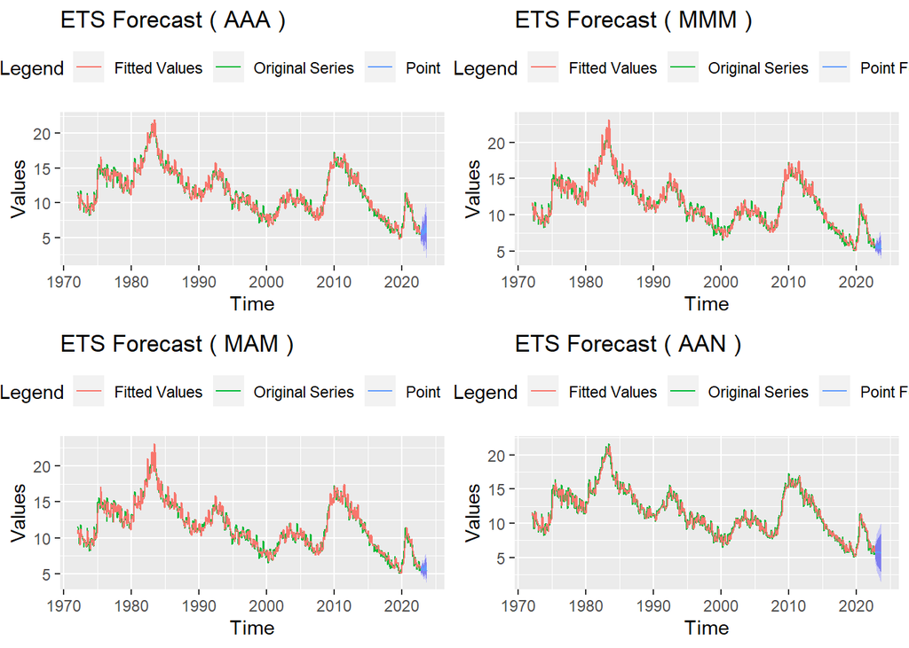

```r
create_ets_plot <- function(model, name) {
  autoplot(model, xlab = "Time", ylab = "Values", main = paste("ETS Forecast (", name, ")")) +
    autolayer(new_train, series = "Original Series") +
    autolayer(fitted(model), series = "Fitted Values") +
    autolayer(model$mean, series = "Point Forecast") +
    guides(colour = guide_legend(title = "Legend")) +
    theme(legend.position = "top")
}
plot1 <- create_ets_plot(frets1, "AAA")
plot2 <- create_ets_plot(frets2, "MMM")
plot3 <- create_ets_plot(frets3, "MAM")
plot4 <- create_ets_plot(frets4, "AAN")
grid.arrange(plot1, plot2, plot3, plot4, ncol = 2)
```

```r
myfit3
```

```
## ETS(M,Ad,M)
##
## Call:
##  ets(y = new_train, model = "MAM")
##
##   Smoothing parameters:
##     alpha = 0.6348
##     beta  = 0.0528
##     gamma = 0.0798
##     phi   = 0.8478
##
##   Initial states:
##     l = 10.7079
##     b = -0.4835
##     s = 0.9267 0.9602 0.9577 0.9835 1.0057 1.0956
##            1.0835 0.9436 0.9699 1.0113 1.039 1.0233
##
##   sigma:  0.0559
##
##      AIC     AICc      BIC
## 3354.266 3355.424 3433.709
```

## Ets Residuals normality

```r
shapiro.test(resid(myfit3))
```

```
##
##  Shapiro-Wilk normality test
##
## data:  resid(myfit3)
## W = 0.99356, p-value = 0.01047
```

residuals do not follow normal distribution for ETS  
# **PROBHET**

```r
#install.packages("prophet")
#install.packages("loo")
library(prophet)
library(fpp)
ds<-c(seq(as.Date("1972/01/01"),as.Date("2022/10/01"),by="month"))
df<-data.frame(ds,y=as.numeric(new_train))
head(df)
```

```
##           ds    y
## 1 1972-01-01 11.6
## 2 1972-02-01 11.5
## 3 1972-03-01 10.7
## 4 1972-04-01  9.2
## 5 1972-05-01  9.3
## 6 1972-06-01 11.8
```

```r
m <- prophet(df)
future <- make_future_dataframe(m, periods = 12, freq = 'month')
```

```r
dim(df)
```

```
## [1] 610   2
```

```r
dim(future)
```

```
## [1] 622   1
```

As you see, we set the forecast horizon using make_future_dataframe

```r
forecast <- predict(m, future)

tail(forecast[c('ds', 'yhat', 'yhat_lower', 'yhat_upper')],12)
```

```
##             ds     yhat yhat_lower yhat_upper
## 611 2022-11-01 5.473010   3.124871   7.918339
## 612 2022-12-01 5.229691   2.998528   7.651354
## 613 2023-01-01 6.126513   3.721932   8.293588
## 614 2023-02-01 5.959140   3.586926   8.285388
## 615 2023-03-01 5.898284   3.605044   8.216593
## 616 2023-04-01 5.282584   2.741963   7.580083
## 617 2023-05-01 5.208659   2.821498   7.317736
## 618 2023-06-01 6.174778   3.933439   8.664374
## 619 2023-07-01 6.148002   3.959237   8.479750
## 620 2023-08-01 5.523907   3.198694   7.828573
## 621 2023-09-01 5.224369   2.982878   7.433843
## 622 2023-10-01 4.986856   2.713034   7.309143
```

## Plot

```r
library(dygraphs)
dyplot.prophet(m, forecast)
```

[interactive chart not shown]

## Accuracy

```r
accuracy(tail(forecast$yhat, 12), new_test)
```

```
##                   ME      RMSE       MAE       MPE     MAPE      ACF1 Theil's U
## Test set -0.03631602 0.4683317 0.3536058 -1.215853 6.695443 0.2451849 0.7648491
```

# **TBATS**

```r
tbatsmodel<-tbats(new_train)
tbatsmodel
```

```
## TBATS(0.866, {0,0}, 0.8, {<12,5>})
##
## Call: tbats(y = new_train)
##
## Parameters
##   Lambda: 0.866193
##   Alpha: 0.5830655
##   Beta: 0.1742711
##   Damping Parameter: 0.8
##   Gamma-1 Values: -0.0003664937
##   Gamma-2 Values: -0.006374737
##
## Seed States:
##              [,1]
##  [1,]  8.08526788
##  [2,]  0.06960364
##  [3,] -0.18737934
##  [4,]  0.36611197
##  [5,] -0.09966732
##  [6,]  0.07010455
##  [7,]  0.09101711
##  [8,]  0.11829016
##  [9,]  0.12003440
## [10,]  0.22541976
## [11,] -0.04126089
## [12,]  0.03730990
## attr(,"lambda")
## [1] 0.8661932
##
## Sigma: 0.4253113
## AIC: 3298.739
```

lambda=0.86 means that the data is transformed by y^0.86 function automatically to achieve stationary in variance. Therefore,we can say that we don’t need to apply Box-Cox transformation before construct TBATS model.  
## Plot

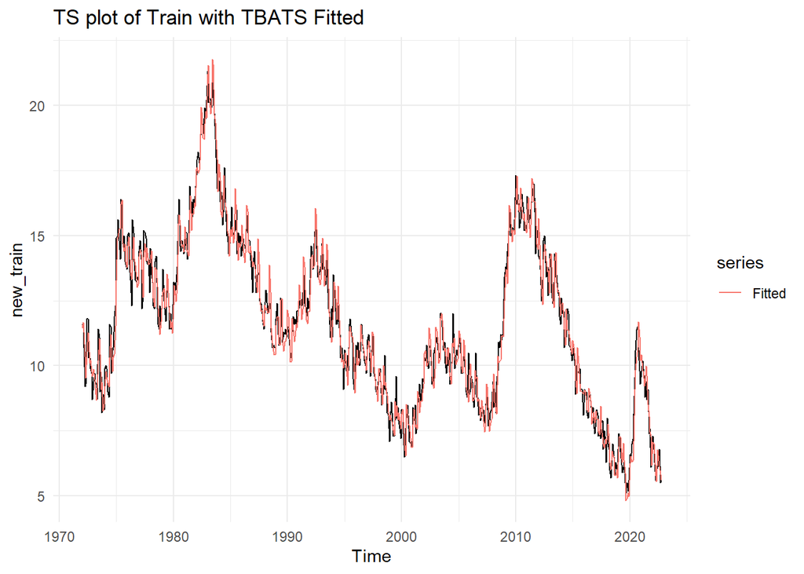

```r
autoplot(new_train,main="TS plot of Train with TBATS Fitted") +autolayer(fitted(tbatsmodel), series="Fitted") +theme_minimal()
```

The model fitted values almost matchs with the true values of the series as shown in the figure.

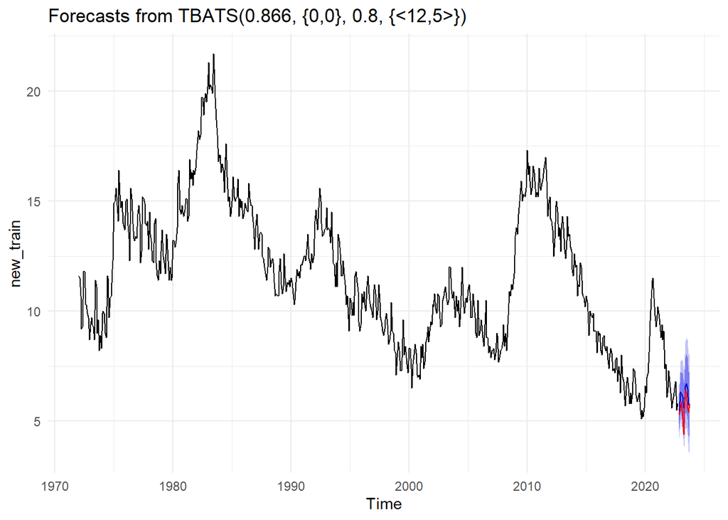

```r
tbats_forecast<-forecast(tbatsmodel,h=12)

autoplot(tbats_forecast)+autolayer(new_test,series="actual",color="red")+theme_minimal()
```

prediction line moves with test data  
## Accuracy

```r
accuracy(tbats_forecast,new_test)
```

```
##                        ME      RMSE       MAE        MPE     MAPE      MASE
## Training set -0.007474644 0.5904739 0.4680215 -0.1949819 4.261474 0.3256945
## Test set     -0.455099949 0.5984135 0.4616787 -8.6751933 8.788620 0.3212806
##                     ACF1 Theil's U
## Training set -0.02283750        NA
## Test set      0.05202526  0.933302
```

## Normality of residuals

```r
shapiro.test(resid(tbatsmodel))
```

```
##
##  Shapiro-Wilk normality test
##
## data:  resid(tbatsmodel)
## W = 0.99891, p-value = 0.977
```

you can see that residual follow normal distribution for TBATS  
# **NNETAR**

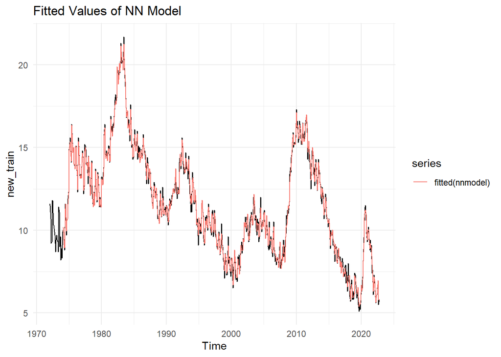

```r
set.seed(497) # I will get the same random initialization each time.Sometimes the set.seed() function does not work either
nnmodel<-nnetar(new_train)
autoplot(new_train)+autolayer(fitted(nnmodel))+theme_minimal()+ggtitle("Fitted Values of NN Model")
```

The model fitted values almost matchs with the true values of the series as shown in the figure  
## Plot

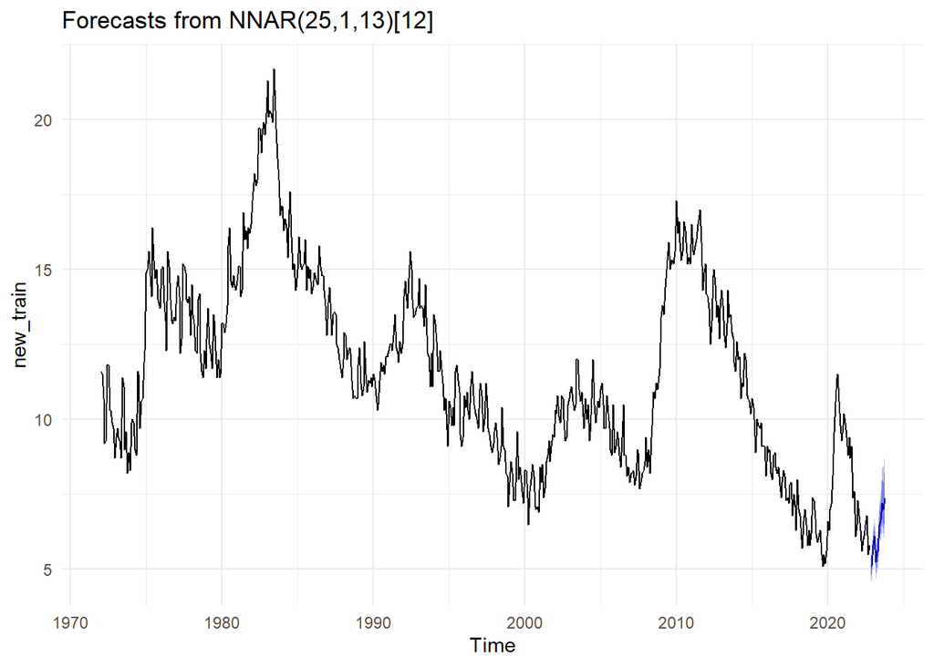

```r
nnforecast<-forecast(nnmodel,h=12,PI=TRUE)
autoplot(nnforecast)+theme_minimal()
```

```r
nnmodel
```

```
## Series: new_train
## Model:  NNAR(25,1,13)[12]
## Call:   nnetar(y = new_train)
##
## Average of 20 networks, each of which is
## a 25-13-1 network with 352 weights
## options were - linear output units
##
## sigma^2 estimated as 0.05747
```

## Accuracy

```r
accuracy(nnforecast,new_test)
```

```
##                        ME      RMSE       MAE         MPE      MAPE      MASE
## Training set  0.001454406 0.2397295 0.1864983  -0.1008066  1.773721 0.1297836
## Test set     -0.540089928 0.8843443 0.6196657 -10.0406351 11.523203 0.4312232
##                     ACF1 Theil's U
## Training set -0.01337999        NA
## Test set      0.47480667  1.363656
```

## Normality of Residuals

```r
shapiro.test(resid(nnforecast))
```

```
##
##  Shapiro-Wilk normality test
##
## data:  resid(nnforecast)
## W = 0.99469, p-value = 0.04047
```

residuals don’t follow normal distribution for NNETAR  
**COMPARISON ACCURACY**

```r
accuracy(tail(forecast$yhat, 610), new_train) # train set of probhet accuracy
```

```
##                 ME     RMSE      MAE       MPE     MAPE      ACF1 Theil's U
## Test set 0.1005007 1.877822 1.499091 -1.812673 13.50299 0.9447774  2.210747
```

```r
sarima_test <- c(0.05957033, 0.4117525, 0.3703203, 0.5521146, 6.761488, 0.1606977)
sarima_train <- c(2.53672474, 2.6629946, 2.5367247, 22.0001093, 22.000109, 0.5694558)

ets_train <- c(-0.007842145, 0.6167292, 0.4870053, -0.2216273, 4.352900,0.04386139)
ets_test <- c(-0.186758840, 0.4291321, 0.3170121, -3.9821607, 6.094475, 0.16950530)

prophet_train <- c(0.1005007, 1.877822, 1.499091, -1.812673, 13.50299, 0.9447774)
prophet_test <- c(-0.03631602, 0.4683317, 0.3536058, -1.215853, 6.695443, 0.2451849)

tbats_train <- c(-0.007474644, 0.5904739, 0.4680215, -0.1949819, 4.261474,-0.02283750)
tbats_test <- c(-0.455099949, 0.5984135, 0.4616787, -8.6751933, 8.788620, 0.05202526)

nnetar_train <- c(0.001454406, 0.2397295, 0.1864983,  -0.1008066,  1.773721,-0.01337999)
nnetar_test <- c(-0.540089928, 0.8843443, 0.6196657, -10.0406351, 11.523203,0.47480667) #The set.seed() function sometimes does not work, so I used the current values while preparing this part of the project. When we run it last time, nn accuracy values may be different, but this difference will not be too big.
```

```r
test_matrix <- rbind(sarima_test, ets_test, prophet_test, tbats_test, nnetar_test)
train_matrix <- rbind(sarima_train, ets_train, prophet_train, tbats_train, nnetar_train)

row_names <- c("ME", "RMSE", "MAE", "MPE", "MAPE", "ACF1")
col_names <- c("sarıma", "ets", "prophet", "tbats", "nnetar")
```

```r
test_matrix <- matrix(test_matrix, nrow = length(row_names), ncol = length(col_names), byrow = TRUE)

train_matrix <- matrix(train_matrix, nrow = length(row_names), ncol = length(col_names), byrow = TRUE)

rownames(test_matrix) <- row_names
colnames(test_matrix) <- col_names

rownames(train_matrix) <- row_names
colnames(train_matrix) <- col_names
```

```r
print("Test Matrix:")
```

```
## [1] "Test Matrix:"
```

```r
print(test_matrix)
```

```
##          sarıma        ets     prophet       tbats      nnetar
## ME   0.05957033 -0.1867588 -0.03631602 -0.45509995  -0.5400899
## RMSE 0.41175250  0.4291321  0.46833170  0.59841350   0.8843443
## MAE  0.37032030  0.3170121  0.35360580  0.46167870   0.6196657
## MPE  0.55211460 -3.9821607 -1.21585300 -8.67519330 -10.0406351
## MAPE 6.76148800  6.0944750  6.69544300  8.78862000  11.5232030
## ACF1 0.16069770  0.1695053  0.24518490  0.05202526   0.4748067
```

```r
print("Training Matrix:")
```

```
## [1] "Training Matrix:"
```

```r
print(train_matrix)
```

```
##          sarıma          ets    prophet        tbats       nnetar
## ME    2.5367247 -0.007842145  0.1005007 -0.007474644  0.001454406
## RMSE  2.6629946  0.616729200  1.8778220  0.590473900  0.239729500
## MAE   2.5367247  0.487005300  1.4990910  0.468021500  0.186498300
## MPE  22.0001093 -0.221627300 -1.8126730 -0.194981900 -0.100806600
## MAPE 22.0001090  4.352900000 13.5029900  4.261474000  1.773721000
## ACF1  0.5694558  0.043861390  0.9447774 -0.022837500 -0.013379990
```

**THE LATEST VERSION OF THE PLOTS**  
# SARIMA

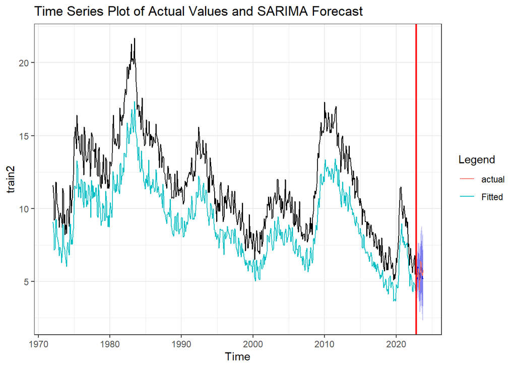

```r
autoplot(f,main=c("Time Series Plot of Actual Values and SARIMA Forecast"), series="forecast" )+
  autolayer(new_test,series = "actual")+
  autolayer(fitted(f), series="Fitted")+
  guides(colour = guide_legend(title = "Legend")) +
  theme(legend.position = "top") +
  geom_vline(xintercept = 2022.8, color = "red", size = 0.8) +
  theme_bw()
```

# ETS

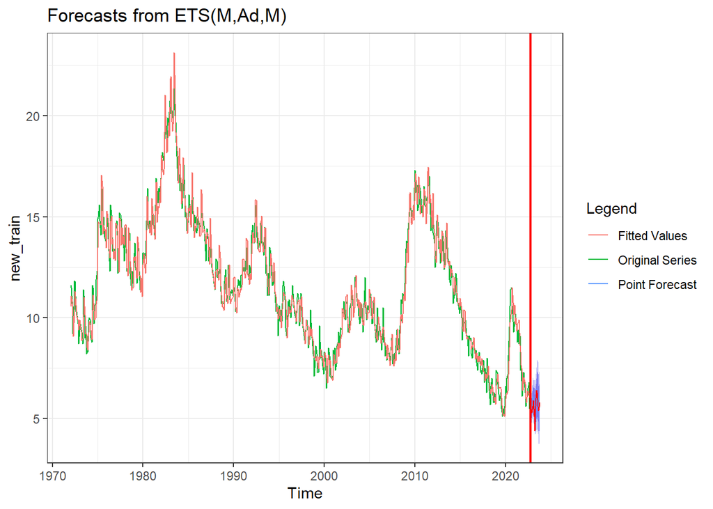

```r
autoplot(frets3) +
    autolayer(new_train, series = "Original Series") +
    autolayer(fitted(frets3), series = "Fitted Values") +
    autolayer(frets3$mean, series = "Point Forecast") +
    autolayer(new_test, series = "Actual", color = "red") +
    guides(colour = guide_legend(title = "Legend")) +
    theme(legend.position = "top") +
    geom_vline(xintercept = 2022.8, color = "red", size = 0.8) +
    theme_bw()
```

# TBATS

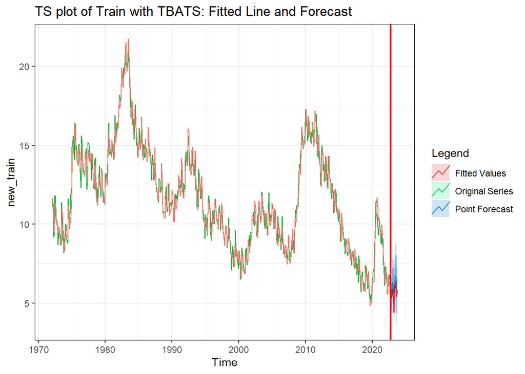

```r
autoplot(new_train, main = "TS plot of Train with TBATS: Fitted Line and Forecast") +
  autolayer(new_train, series = "Original Series") +
  autolayer(fitted(tbatsmodel), series = "Fitted Values") +
  autolayer(tbats_forecast, series = "Point Forecast") +
  autolayer(new_test, series = "Actual", color = "red") +
  guides(colour = guide_legend(title = "Legend")) +
  theme(legend.position = "top") +
  geom_vline(xintercept = 2022.8, color = "red", size = 0.8) +
  theme_bw()
```

# NNETAR

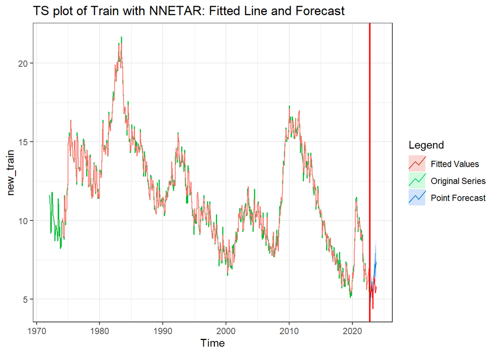

```r
autoplot(new_train, main = "TS plot of Train with NNETAR: Fitted Line and Forecast") +
  autolayer(new_train, series = "Original Series") +
  autolayer(fitted(nnmodel), series = "Fitted Values") +
  autolayer(nnforecast, series = "Point Forecast") +
  autolayer(new_test, series = "Actual", color = "red") +
  guides(colour = guide_legend(title = "Legend")) +
  theme(legend.position = "top") +
  geom_vline(xintercept = 2022.8, color = "red", size = 0.8) +
  theme_bw()
```